# Project 3

Akshay_Gupta_36-600_Project_3

### Load necessary libraries

```r
suppressPackageStartupMessages(library(tidyverse))    # For data manipulation and plotting
suppressPackageStartupMessages(library(gridExtra))    # For arranging multiple grid-based plots
suppressPackageStartupMessages(library(corrplot))     # For creating correlation matrix plots
suppressPackageStartupMessages(library(randomForest)) # For Random Forest models
suppressPackageStartupMessages(library(caret))        # For data partitioning, cross-validation, and model training
suppressPackageStartupMessages(library(pROC))          # For ROC curve analysis and AUC calculation
suppressPackageStartupMessages(library(rpart.plot))    # For plotting decision trees
```

```r
wine_data <- read.csv("wineQuality.csv")

str(wine_data)
```

```
## 'data.frame':    6497 obs. of  12 variables:
##  $ fix.acid : num  6.9 7.6 10.4 6.8 11.4 6.5 6.1 9.5 7.6 6.7 ...
##  $ vol.acid : num  0.19 0.2 0.38 0.35 0.625 0.29 0.26 0.885 0.16 0.42 ...
##  $ citric   : num  0.32 0.3 0.46 0.32 0.66 0.25 0.51 0.27 0.44 0.39 ...
##  $ sugar    : num  7.9 14.2 2.1 2.4 6.2 2.5 2.2 2.3 1.4 12.1 ...
##  $ chlorides: num  0.042 0.056 0.104 0.048 0.088 0.142 0.05 0.084 0.043 0.04 ...
##  $ free.sd  : num  30 53 6 35 6 8 61 31 25 61 ...
##  $ total.sd : num  130 212 10 103 24 ...
##  $ density  : int  2 2 2 2 2 2 2 2 2 2 ...
##  $ pH       : num  3.4 3.14 3.12 3.28 3.11 3 3.08 3.24 3.11 3.31 ...
##  $ sulphates: num  0.39 0.46 0.65 0.46 0.99 0.44 0.6 0.53 0.75 0.58 ...
##  $ alcohol  : num  10.5 8.9 11.8 12 13.3 9.9 9.8 9.4 10.3 9.7 ...
##  $ label    : chr  "GOOD" "GOOD" "GOOD" "GOOD" ...
```

```r
summary(wine_data)
```

```
##     fix.acid         vol.acid          citric           sugar
##  Min.   : 3.800   Min.   :0.0800   Min.   :0.0000   Min.   : 0.600
##  1st Qu.: 6.400   1st Qu.:0.2300   1st Qu.:0.2500   1st Qu.: 1.800
##  Median : 7.000   Median :0.2900   Median :0.3100   Median : 3.000
##  Mean   : 7.215   Mean   :0.3397   Mean   :0.3186   Mean   : 5.443
##  3rd Qu.: 7.700   3rd Qu.:0.4000   3rd Qu.:0.3900   3rd Qu.: 8.100
##  Max.   :15.900   Max.   :1.5800   Max.   :1.6600   Max.   :65.800
##    chlorides          free.sd          total.sd        density
##  Min.   :0.00900   Min.   :  1.00   Min.   :  6.0   Min.   :1.00
##  1st Qu.:0.03800   1st Qu.: 17.00   1st Qu.: 77.0   1st Qu.:2.00
##  Median :0.04700   Median : 29.00   Median :118.0   Median :2.00
##  Mean   :0.05603   Mean   : 30.53   Mean   :115.7   Mean   :1.97
##  3rd Qu.:0.06500   3rd Qu.: 41.00   3rd Qu.:156.0   3rd Qu.:2.00
##  Max.   :0.61100   Max.   :289.00   Max.   :440.0   Max.   :3.00
##        pH          sulphates         alcohol         label
##  Min.   :2.720   Min.   :0.2200   Min.   : 8.00   Length:6497
##  1st Qu.:3.110   1st Qu.:0.4300   1st Qu.: 9.50   Class :character
##  Median :3.210   Median :0.5100   Median :10.30   Mode  :character
##  Mean   :3.219   Mean   :0.5313   Mean   :10.49
##  3rd Qu.:3.320   3rd Qu.:0.6000   3rd Qu.:11.30
##  Max.   :4.010   Max.   :2.0000   Max.   :14.90
```

```r
colSums(is.na(wine_data)) # no 'na' values
```

```
##  fix.acid  vol.acid    citric     sugar chlorides   free.sd  total.sd   density
##         0         0         0         0         0         0         0         0
##        pH sulphates   alcohol     label
##         0         0         0         0
```

### Pre-processing

```r
# Ensure Correct Data Types
wine_data$density <- factor(wine_data$density, levels = c(1, 2, 3))
wine_data$label <- factor(wine_data$label, levels = c("BAD", "GOOD")) # target variable

# Split Data
set.seed(42)
train_index <- sample(seq_len(nrow(wine_data)), size = 0.7 * nrow(wine_data))
train_data <- wine_data[train_index, ]
test_data <- wine_data[-train_index, ]


pre_process <- preProcess(train_data[, -ncol(train_data)], method = c("center", "scale"))
train_data_scaled <- predict(pre_process, train_data)
test_data_scaled <- predict(pre_process, test_data)
```

I did a 70%-30% split for the training and test data since the dataset size is large. I did this rather than a 80%-20% split as it reduces model overfitting and gives a larger test set for model evaluation. The split is random to ensure that the distribution of variables are similar.

### Exploratory Data Analysis (EDA)

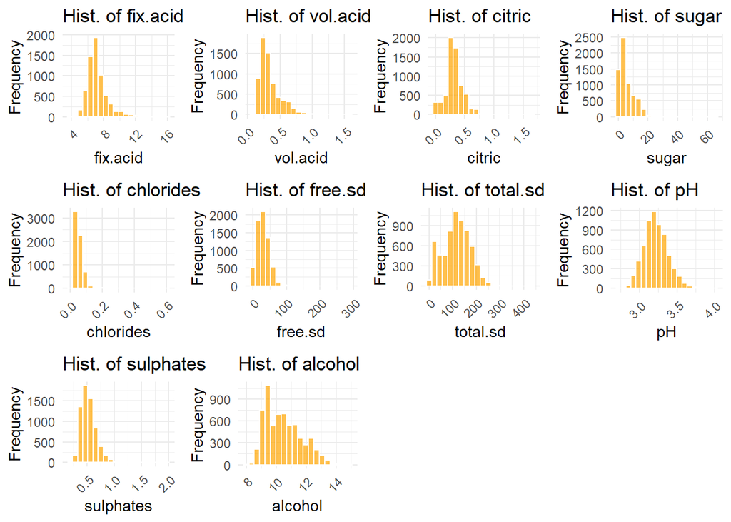

```r
# Create histograms for each continuous variable distributions
continuous_vars <- names(wine_data)[sapply(wine_data, is.numeric) & !(names(wine_data) %in% c("label", "density"))] # exclude categorical variables

# Create an empty list to store all plots
plot_list <- list()

# Generate histograms and store them in the list
for (var in continuous_vars) {
  plot_list[[var]] <- ggplot(wine_data, aes(x = .data[[var]])) +
    geom_histogram(bins = 20, fill = "orange", color = "white", alpha = 0.7) +
    labs(title = paste("Hist. of", var), x = var, y = "Frequency") +
    theme_minimal() +
    theme(axis.text.x = element_text(angle = 45, hjust = 1))
}

# Use grid.arrange to display the plots in a grid
grid.arrange(grobs = plot_list, ncol = 4)  # Adjust `ncol` for desired number of columns
```

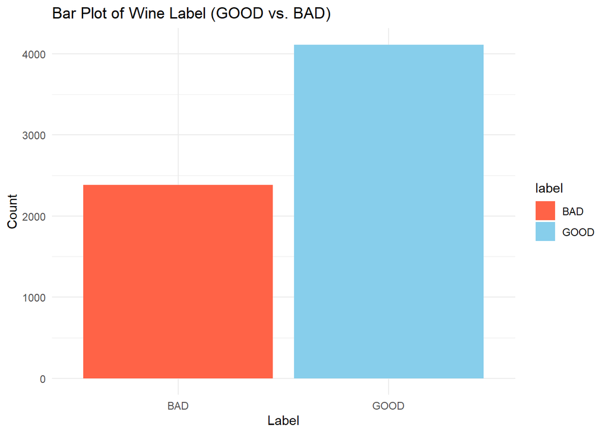

```r
# Define a consistent color palette
label_colors <- c(GOOD = "skyblue", BAD = "tomato")

# Bar plot for 'label' (GOOD vs. BAD)
ggplot(wine_data, aes(x = label, fill = label)) +
  geom_bar() +
  scale_fill_manual(values = label_colors) +  # Apply custom colors
  labs(title = "Bar Plot of Wine Label (GOOD vs. BAD)", x = "Label", y = "Count") +
  theme_minimal()
```

```r
# Check the distribution of the response variable (label)
table(wine_data$label)
```

```
##
##  BAD GOOD
## 2384 4113
```

```r
prop.table(table(wine_data$label))
```

```
##
##       BAD      GOOD
## 0.3669386 0.6330614
```

```r
# Check the distribution of density
table(wine_data$density)
```

```
##
##    1    2    3
##  345 6005  147
```

```r
prop.table(table(wine_data$density))
```

```
##
##          1          2          3
## 0.05310143 0.92427274 0.02262583
```

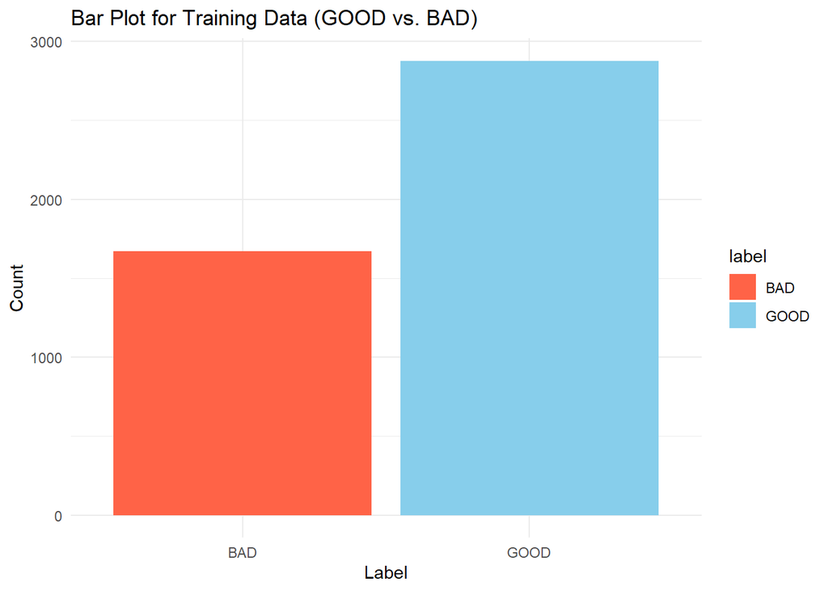

```r
# For training data
ggplot(train_data, aes(x = label, fill = label)) +
  geom_bar() +
  scale_fill_manual(values = label_colors) +  # Apply custom colors
  labs(title = "Bar Plot for Training Data (GOOD vs. BAD)", x = "Label", y = "Count") +
  theme_minimal()
```

```r
prop.table(table(train_data$label))
```

```
##
##       BAD      GOOD
## 0.3672751 0.6327249
```

```r
prop.table(table(train_data$density))
```

```
##
##          1          2          3
## 0.05300198 0.92324610 0.02375192
```

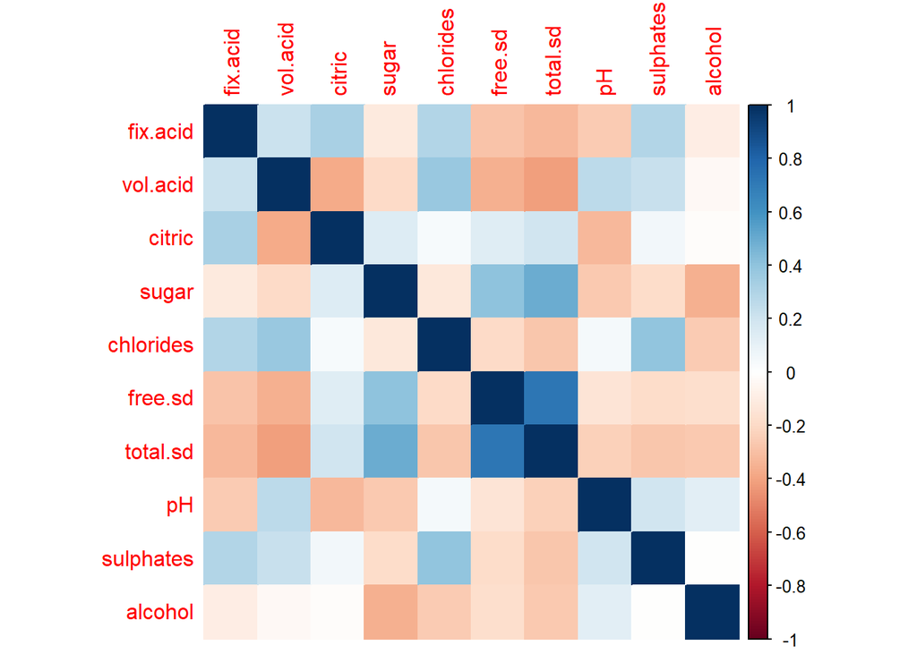

```r
# Variable correlations heatmap
numeric_data <- wine_data[, sapply(wine_data, is.numeric)] # Exclude non-numeric columns (e.g., 'label' and 'density')
corr_matrix <- cor(numeric_data)
corrplot(corr_matrix, method = "color")
```

From the distributions of the continuous data, the ‘sugar’ and ‘chlorides’ variables are the most right skewed. The distributions of the labels are consistent between the full dataset and the training data. The variables do not have any major high correlation issues.

### Check Distributions After Scaling

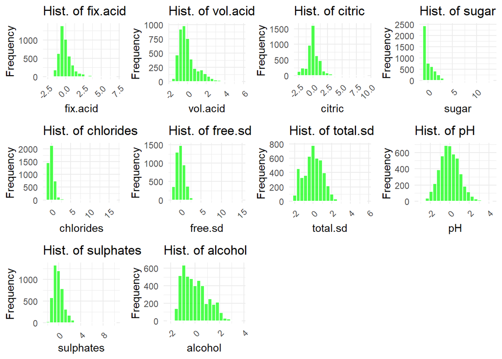

```r
# Create histograms for each continuous variable distributions
# Create an empty list to store all plots
plot_list <- list()

# Generate histograms and store them in the list
for (var in continuous_vars) {
  plot_list[[var]] <- ggplot(train_data_scaled, aes(x = .data[[var]])) +
    geom_histogram(bins = 20, fill = "green", color = "white", alpha = 0.7) +
    labs(title = paste("Hist. of", var), x = var, y = "Frequency") +
    theme_minimal() +
    theme(axis.text.x = element_text(angle = 45, hjust = 1))
}

# Use grid.arrange to display the plots in a grid
grid.arrange(grobs = plot_list, ncol = 4)  # Adjust `ncol` for desired number of columns
```

The distributions are scaled and centered around 0.

### Logistic Regression Model

```r
# Define a grid of possible values for regularization (lambda) and alpha (L1/L2)
tune_grid <- expand.grid(alpha = c(0, 0.5, 1),  # alpha: 0 is L2 (Ridge), 1 is L1 (Lasso), 0.5 is elastic net
                        lambda = seq(0, 1, by = 0.1))  # lambda: strength of the regularization

# Train a Logistic Regression Model with regularization tuning
set.seed(42)
logistic_model <- train(label ~ ., data = train_data_scaled, method = "glmnet", family = "binomial",
                        tuneGrid = tune_grid)
```

### Analysis of Logistic Regression Model

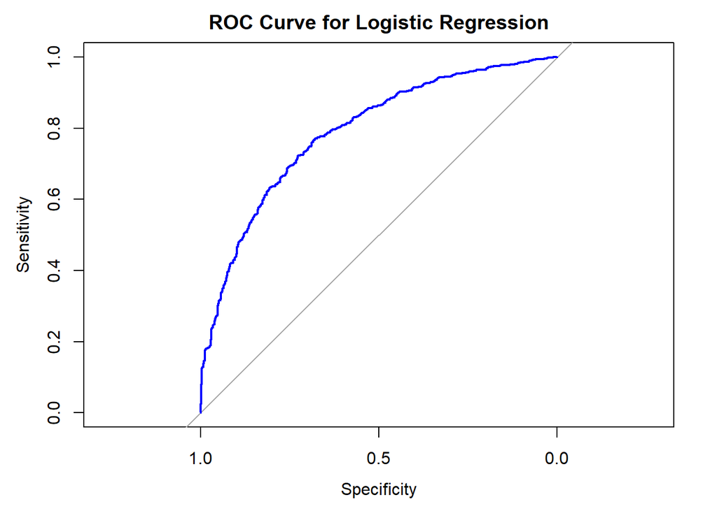

```r
# Predict probabilities for the positive class ('GOOD')
logistic_predictions <- predict(logistic_model, newdata = test_data_scaled, type = "prob")

# ROC Curve using the probabilities for the positive class ('GOOD')
roc_curve_log <- roc(test_data_scaled$label, logistic_predictions$GOOD)  # 'GOOD' is the positive class
# Plot ROC Curve
plot(roc_curve_log, main = "ROC Curve for Logistic Regression", col = "blue")
```

```r
# AUC (Area Under the Curve)
auc_value_log <- auc(roc_curve_log)
cat("AUC (Logistic): ", auc_value_log, "\n")
```

```
## AUC (Logistic):  0.7898027
```

```r
# Youden's J (Optimal Threshold)
youden_j_log <- coords(roc_curve_log, "best", ret = "all")
optimal_threshold <- youden_j_log$threshold
cat("Youden's J (Logistic): ", optimal_threshold, "\n")
```

```
## Youden's J (Logistic):  0.5831809
```

```r
# Apply optimal threshold to classify the test set
predicted_class_log <- factor(ifelse(logistic_predictions$GOOD > optimal_threshold, "GOOD", "BAD"),
                          levels = c("BAD", "GOOD"))

# Confusion Matrix with the optimal threshold
conf_matrix_log <- confusionMatrix(predicted_class_log, test_data_scaled$label)
print(conf_matrix_log$table)  # Only the confusion matrix
```

```
##           Reference
## Prediction BAD GOOD
##       BAD  488  288
##       GOOD 226  948
```

```r
# Misclassification Rate (1 - Accuracy)
misclassification_rate_log <- 1 - conf_matrix_log$overall['Accuracy']
cat("Misclassification Rate (Logistic): ", misclassification_rate_log, "\n")
```

```
## Misclassification Rate (Logistic):  0.2635897
```

```r
# Output the best tuning parameters (alpha and lambda) for the final model
cat("Best Alpha: ", logistic_model$bestTune$alpha, "\n")
```

```
## Best Alpha:  0.5
```

```r
cat("Best Lambda: ", logistic_model$bestTune$lambda, "\n")
```

```
## Best Lambda:  0
```

Logistic Regression for classification performs reasonably well with a AUC of 0.79 and a misclassification rate of 0.26. Using an elastic net for logistic regression is better than using ridge or lasso.

### Decision Tree Classification

```r
set.seed(42)
tree_model <- train(label ~ ., data = train_data_scaled, method = "rpart",
                    tuneGrid = expand.grid(cp = seq(0, 0.1, by = 0.005))) # Tune the 'cp' parameter to control tree complexity and pruning
```

### Analysis of Decision Tree Classification

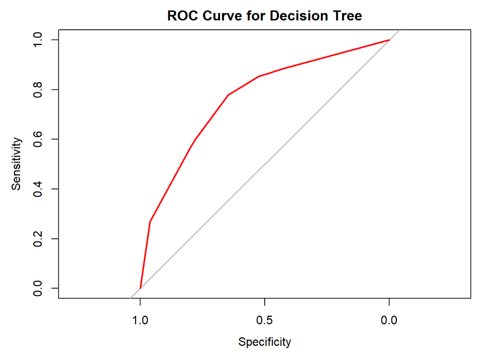

```r
# Predict probabilities (not classes) using the Decision Tree model
tree_predictions <- predict(tree_model, newdata = test_data_scaled, type = "prob")

# ROC Curve for Decision Tree
roc_curve_tree <- roc(test_data_scaled$label, tree_predictions$GOOD)
plot(roc_curve_tree, main = "ROC Curve for Decision Tree", col = "red")
```

```r
# AUC (Area Under the Curve) for Decision Tree
auc_value_tree <- auc(roc_curve_tree)
cat("AUC (Decision Tree): ", auc_value_tree, "\n")
```

```
## AUC (Decision Tree):  0.76263
```

```r
# Youden's J (Optimal Threshold) for Decision Tree
youden_j_tree <- coords(roc_curve_tree, "best", ret = "all")
optimal_threshold_tree <- youden_j_tree$threshold
cat("Youden's J (Decision Tree): ", optimal_threshold_tree, "\n")
```

```
## Youden's J (Decision Tree):  0.6198314
```

```r
# Apply optimal threshold to classify the test set
predicted_class_tree <- factor(ifelse(tree_predictions$GOOD > optimal_threshold_tree, "GOOD", "BAD"),
                               levels = c("BAD", "GOOD"))

# Confusion Matrix with the optimal threshold for Decision Tree
confusion_matrix_tree <- confusionMatrix(predicted_class_tree, test_data_scaled$label)
print(confusion_matrix_tree$table)
```

```
##           Reference
## Prediction BAD GOOD
##       BAD  462  273
##       GOOD 252  963
```

```r
# Misclassification Rate for Decision Tree
misclassification_rate_tree <- 1 - confusion_matrix_tree$overall['Accuracy']
cat("Misclassification Rate (Decision Tree): ", misclassification_rate_tree, "\n")
```

```
## Misclassification Rate (Decision Tree):  0.2692308
```

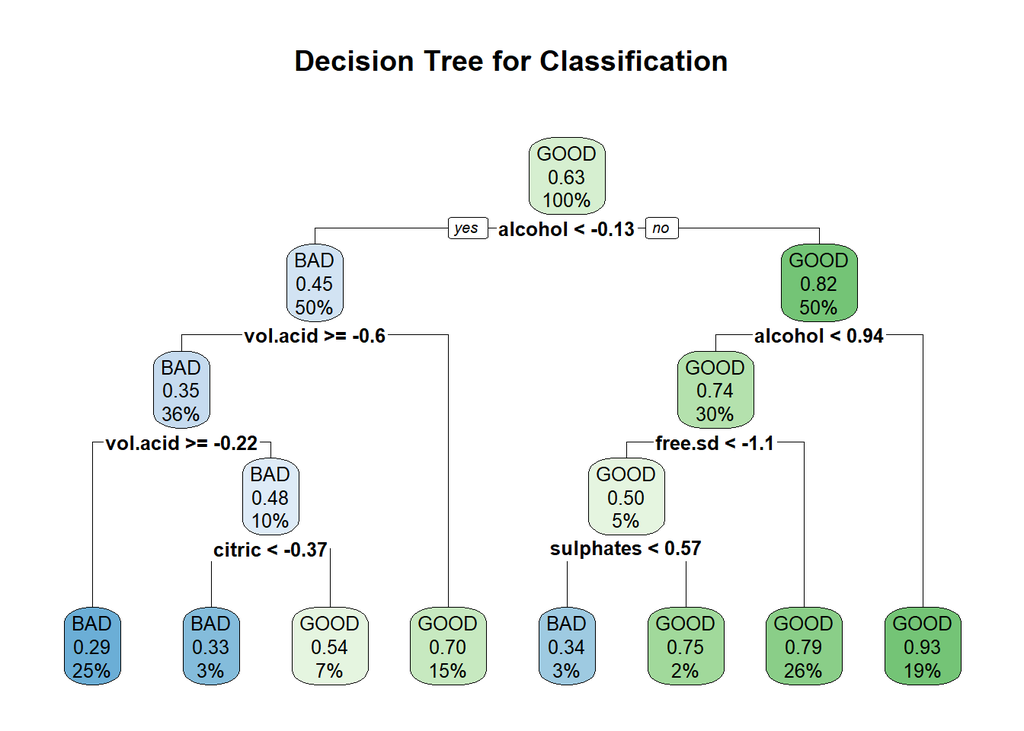

```r
# Plot the Decision Tree
rpart.plot(tree_model$finalModel, main = "Decision Tree for Classification",
           extra = 106,  # Show additional information (e.g., node counts, probabilities)
           fallen.leaves = TRUE,  # Position the leaf nodes at the bottom of the plot
           cex = 0.8)  # Adjust text size
```

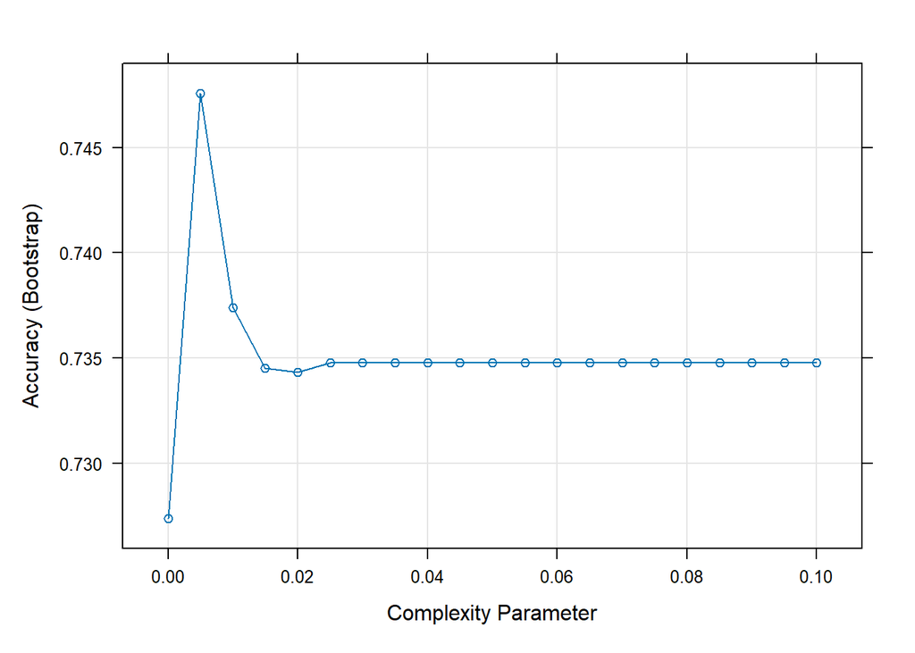

```r
plot(tree_model)
```

Most of the dataset is important when it comes to pruning for decision tree modeling. Using a cp of 0.005, minimal pruining is done to obtain the lowest misclassification rate and highest accuracy.

### Random Forest Classification

```r
set.seed(42)
rf_model <- train(label ~ ., data = train_data_scaled, method = "rf",
                  tuneGrid = expand.grid(mtry = c(2, 5, 8, 11)))
```

### Analysis of Random Forest Classification

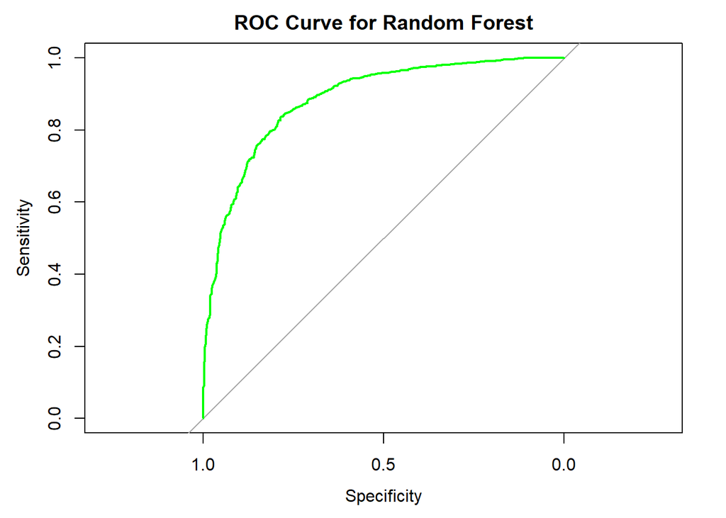

```r
# Predict probabilities (not classes) using the Random Forest model
rf_predictions <- predict(rf_model, newdata = test_data_scaled, type = "prob")

# ROC Curve for Random Forest
roc_curve_rf <- roc(test_data_scaled$label, rf_predictions$GOOD)
plot(roc_curve_rf, main = "ROC Curve for Random Forest", col = "green")
```

```r
# AUC (Area Under the Curve) for Random Forest
auc_value_rf <- auc(roc_curve_rf)
cat("AUC (Random Forest): ", auc_value_rf, "\n")
```

```
## AUC (Random Forest):  0.8842425
```

```r
# Youden's J (Optimal Threshold) for Random Forest
youden_j_rf <- coords(roc_curve_rf, "best", ret = "all")
optimal_threshold_rf <- youden_j_rf$threshold
cat("Youden's J (Random Forest): ", optimal_threshold_rf, "\n")
```

```
## Youden's J (Random Forest):  0.597
```

```r
# Apply optimal threshold to classify the test set
predicted_class_rf <- factor(ifelse(rf_predictions$GOOD > optimal_threshold_rf, "GOOD", "BAD"),
                             levels = c("BAD", "GOOD"))

# Confusion Matrix with the optimal threshold for Random Forest
confusion_matrix_rf <- confusionMatrix(predicted_class_rf, test_data_scaled$label)
print(confusion_matrix_rf$table)
```

```
##           Reference
## Prediction  BAD GOOD
##       BAD   561  203
##       GOOD  153 1033
```

```r
# Misclassification Rate for Random Forest
misclassification_rate_rf <- 1 - confusion_matrix_rf$overall['Accuracy']
cat("Misclassification Rate (Random Forest): ", misclassification_rate_rf, "\n")
```

```
## Misclassification Rate (Random Forest):  0.1825641
```

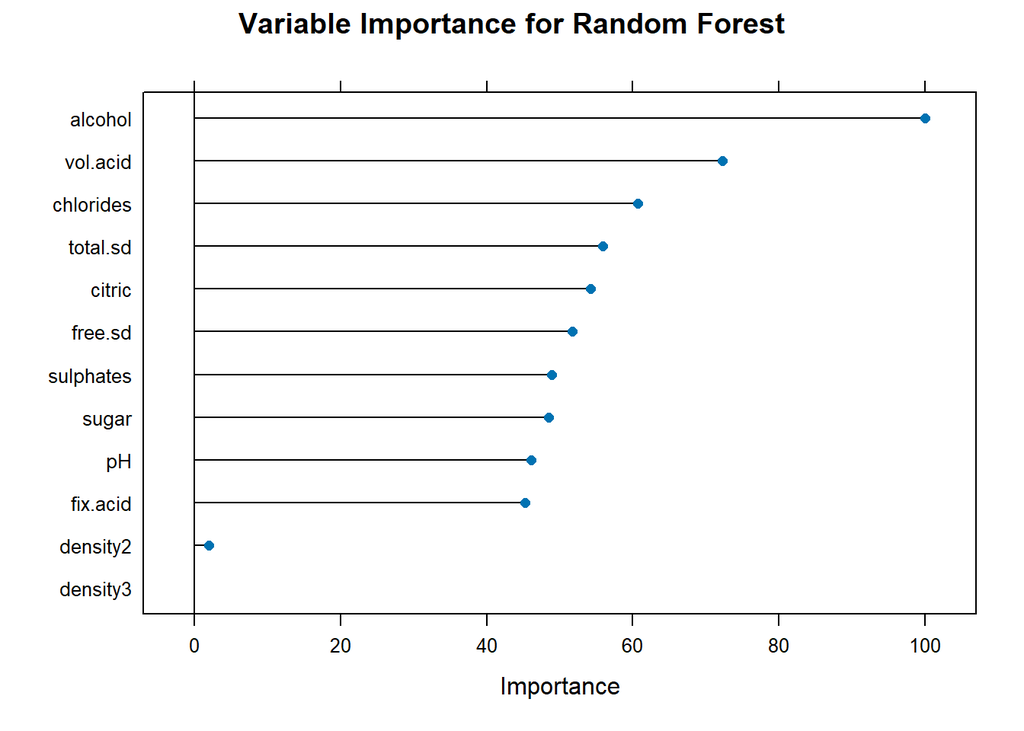

```r
# Plot Variable Importance
var_imp_rf <- varImp(rf_model, scale = TRUE)
plot(var_imp_rf, main = "Variable Importance for Random Forest")
```

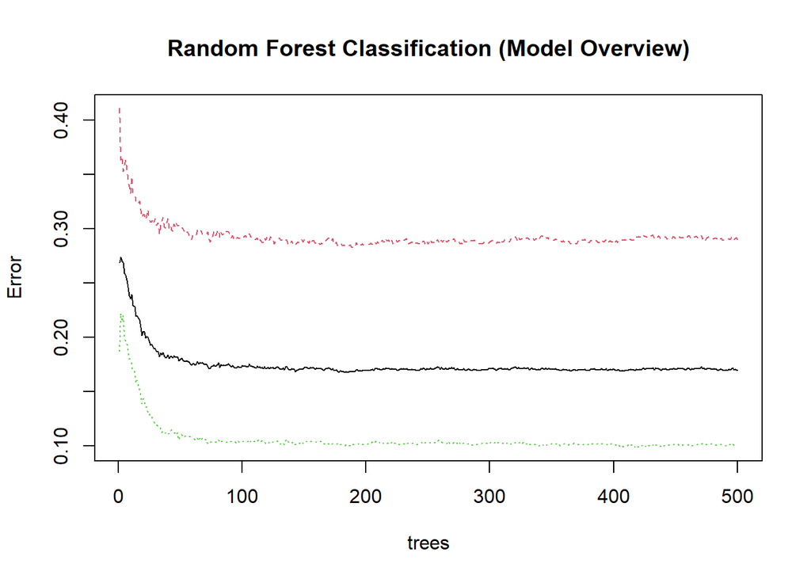

```r
# Plot the Random Forest Model (using caret package's default plot)
plot(rf_model$finalModel, main = "Random Forest Classification (Model Overview)")
```

```r
# Check the best mtry value selected
best_mtry <- rf_model$bestTune$mtry
cat("Best mtry value: ", best_mtry, "\n")
```

```
## Best mtry value:  2
```

From the variable importance plot, we can see that alcohol is the most important variable while density is the least important variable. Density can be removed for improving the predictive models. Using an mtry value of 2 gives the best random forest model indicating that only 2 features are considered for splitting the trees. From the model overview plot, using 80 trees is ideal for reducing error as the error gradient tails off after that.

### K-Nearest Neighbors Classification

```r
set.seed(42)
knn_model <- train(label ~ ., data = train_data_scaled, method = "knn",
                   tuneGrid = expand.grid(k = seq(1, 30, by = 1)))
```

### Analysis of K-Nearest Neighbors Classification

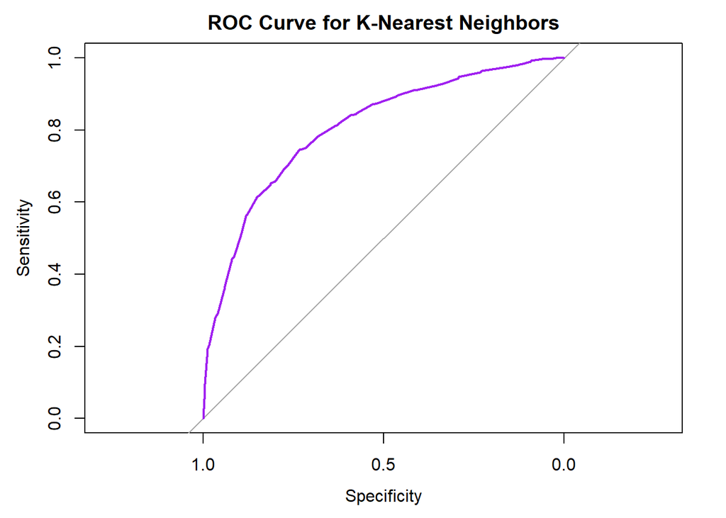

```r
# Predict probabilities (not classes) using the K-Nearest Neighbors model
knn_predictions <- predict(knn_model, newdata = test_data_scaled, type = "prob")

# ROC Curve for K-Nearest Neighbors
roc_curve_knn <- roc(test_data_scaled$label, knn_predictions$GOOD)
plot(roc_curve_knn, main = "ROC Curve for K-Nearest Neighbors", col = "purple")
```

```r
# AUC (Area Under the Curve) for K-Nearest Neighbors
auc_value_knn <- auc(roc_curve_knn)
cat("AUC (K-Nearest Neighbors): ", auc_value_knn, "\n")
```

```
## AUC (K-Nearest Neighbors):  0.8051969
```

```r
# Youden's J (Optimal Threshold) for K-Nearest Neighbors
youden_j_knn <- coords(roc_curve_knn, "best", ret = "all")
optimal_threshold_knn <- youden_j_knn$threshold
cat("Youden's J (K-Nearest Neighbors): ", optimal_threshold_knn, "\n")
```

```
## Youden's J (K-Nearest Neighbors):  0.6380952
```

```r
# Apply optimal threshold to classify the test set
predicted_class_knn <- factor(ifelse(knn_predictions$GOOD > optimal_threshold_knn, "GOOD", "BAD"),
                              levels = c("BAD", "GOOD"))

# Confusion Matrix with the optimal threshold for K-Nearest Neighbors
confusion_matrix_knn <- confusionMatrix(predicted_class_knn, test_data_scaled$label)
print(confusion_matrix_knn$table)
```

```
##           Reference
## Prediction BAD GOOD
##       BAD  523  315
##       GOOD 191  921
```

```r
# Misclassification Rate for K-Nearest Neighbors
misclassification_rate_knn <- 1 - confusion_matrix_knn$overall['Accuracy']
cat("Misclassification Rate (K-Nearest Neighbors): ", misclassification_rate_knn, "\n")
```

```
## Misclassification Rate (K-Nearest Neighbors):  0.2594872
```

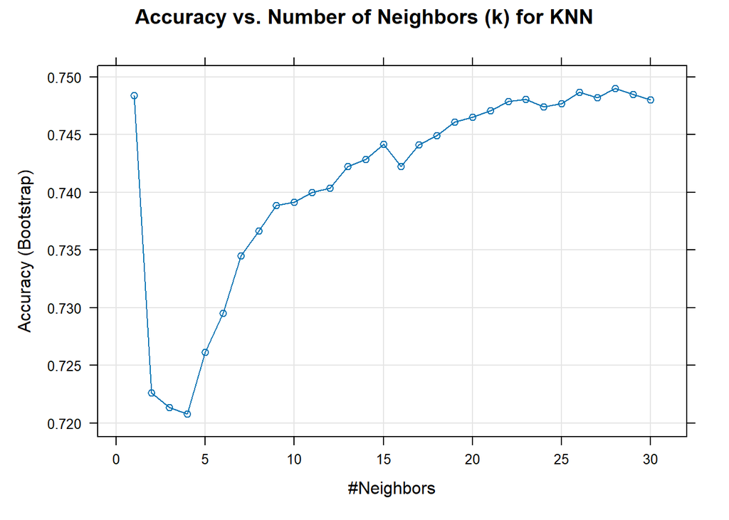

```r
# Plot the Accuracy vs. k
plot(knn_model, main = "Accuracy vs. Number of Neighbors (k) for KNN")
```

```r
# Best k value
best_k <- knn_model$bestTune$k
cat("Best k (Number of Neighbors): ", best_k, "\n")
```

```
## Best k (Number of Neighbors):  28
```

From the accuracy versus number of k neighbors plot, we can see that k=28 give an optimal KNN prediction model. Setting the k to 1 causes overfitting, increasing sensitivity to noise and is not a good practice for prediction modeling and will not produce good results with new datasets.

### ROC AUC Comparison of the Models

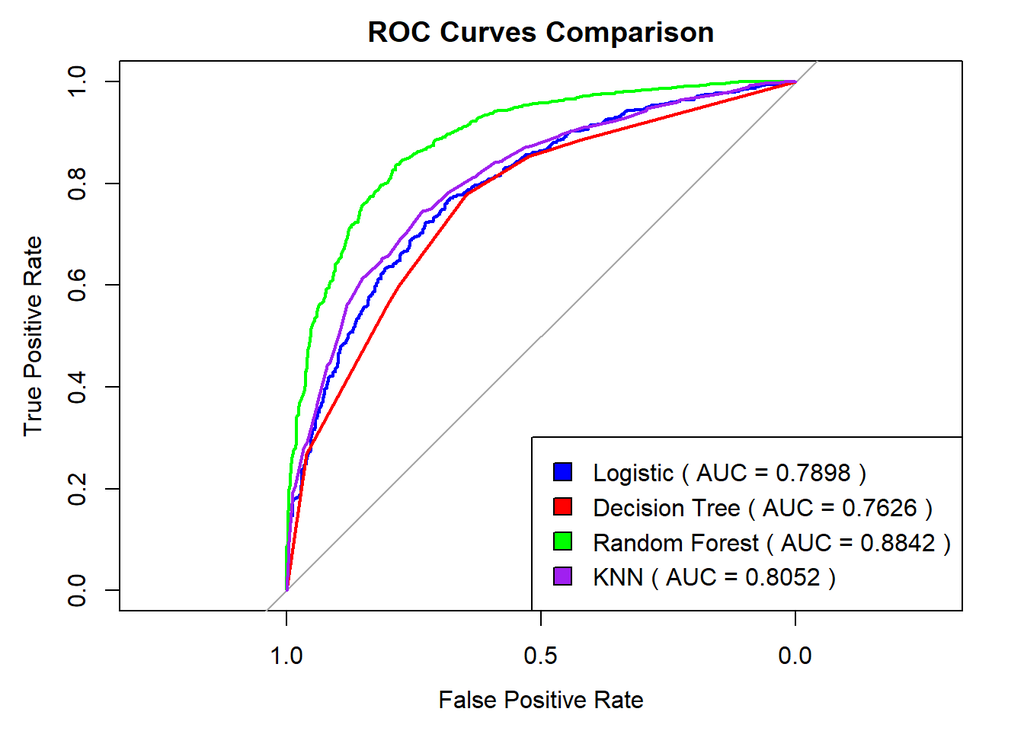

```r
# Plot the ROC curve for Logistic Regression
roc_plot <-plot(roc_curve_log, col = "blue", main = "ROC Curves Comparison", xlim = c(1, 0), ylim = c(0, 1),
                xlab = "False Positive Rate", ylab = "True Positive Rate", lwd = 2)
# Add ROC curves for other models
lines(roc_curve_tree, col = "red", lwd = 2)  # Decision Tree
lines(roc_curve_rf, col = "green", lwd = 2)  # Random Forest
lines(roc_curve_knn, col = "purple", lwd = 2)  # KNN

# Add AUC values to the legend
legend("bottomright",
       legend = c(paste("Logistic ( AUC =", round(auc_value_log, 4), ")"),
                  paste("Decision Tree ( AUC =", round(auc_value_tree, 4), ")"),
                  paste("Random Forest ( AUC =", round(auc_value_rf, 4), ")"),
                  paste("KNN ( AUC =", round(auc_value_knn, 4), ")")),
       fill = c("blue", "red", "green", "purple"))
```

```r
# Create a table with models, AUC, and misclassification rates
model_stats <- data.frame(
  Model = c("Logistic Regression", "Decision Tree", "Random Forest", "KNN"),
  AUC = c(round(auc_value_log, 4), round(auc_value_tree, 4), round(auc_value_rf, 4), round(auc_value_knn, 4)),
  MisclassificationRate = c(round(misclassification_rate_log, 4),
                            round(misclassification_rate_tree, 4),
                            round(misclassification_rate_rf, 4),
                            round(misclassification_rate_knn, 4))
)
print(model_stats)
```

```
##                 Model    AUC MisclassificationRate
## 1 Logistic Regression 0.7898                0.2636
## 2       Decision Tree 0.7626                0.2692
## 3       Random Forest 0.8842                0.1826
## 4                 KNN 0.8052                0.2595
```

Using Youden’s J to find the optimal threshold is significantly better for classification compared to setting the threshold to 0.5 since every binary dataset would have it’s own ideal threshold.

From the 4 models, we can see that random forest classification performs the best with the optimal threshold using Youden’s J with a AUC of 0.88 and a misclassification rate of 0.18. Logistic, Decision Tree, and KNN classification perform significantly worse than random forest, with AUCs of 0.79, 0.76, and 0.80 respectively. With different data splits and parameters for each model, the performances vary a bit but RF performs the best overall.

This is probably because RF uses multiple decision trees and considers features importance in it’s modeling.